# Introduction

Until now, we have been talking about government spending and taxes as if the government could take on as much debt as it wants. But then, why doesn’t the government just engage in more tax cutting and more government spending, or both? We alluded to a first reason when we talked about the consequences of having $1-c_1<b_1$, or the propensity to save be less than the propensity to invest. We argued then that we would never be in a Keynesian situation of deficient aggregate demand, so that multiplier effects would stop when facing constraints on supply. Similarly, if the government started to make public saving very negative (running a budget deficit), then it would similarly start facing constraints on what the economy can supply. For instance, if fiscal policy was too accommodative, and to the limit if $G$ was set at too high a value, then supply constraints would start to bite: one example was given historically in the 1940s when the U.S. engaged in World War II. However, these levels of spending are clearly out of the question, and this is perhaps not what constrains the government from doing a little bit more spending, or a little bit more tax reductions.

Another potentially more pressing issue is that of the government deficit, and the impact of government debt on future generations. The Trump tax cuts which have just been enacted have reduced unemployment to historically low levels, and pushed GDP growth up to a level which has not been seen in a long time, as predicted by the Keynesian model; however, it also has raised U.S. public debt, and is being criticized mostly on these grounds. This makes sense: when government spending increases $\Delta G>0$, this leads to a government deficit of equal magnitude: $\Delta (T-G) = -\Delta G<0.$ Similarly, a tax cut $\Delta T<0$ leads to increased deficits given by $\Delta (T-G) = \Delta T<0$.[^1] One might worry that this debt will someday have to be repaid, and that the current generation is simply putting a burden on future generations. In this case, higher GDP today might only be thought of as leading to lower GDP in the future, when aggregate demand will be diminished.

During this lecture, we make three related points concerning government deficits and government debt:

1. We show first, without using any economic model, that simple accounting suggests that public debt is on a sustainable path whenever the real interest rate on public debt is lower than the rate of growth of GDP ($r<g$), a situation called “dynamic inefficiency” for reasons that will become clear later. (from problem set 4 you may already remember that the Golden Rule level of capital accumulation corresponded to $r=g$). I shall argue that real interest rates appear to be below the rate of growth of GDP, at least for now, so there does not seem to be cause for alarm - at least, until interest rates don’t rise more.
2. Second, I illustrate using an economic model that it is not true that public debt necessarily will need to be repaid eventually, so that government debt is not necessarily a burden on future generations - an argument which is often made in the public debate. In the overlapping generations model of lecture 4, and provided that capital accumulation is above the Golden Rule level ($r<g$), so that there is **dynamic inefficiency**, public debt is never repaid, as there are always new generations coming along, who buy government debt when they are young and sell it to the next generation when old. This is sustainable if $r<g$, for reasons laid out in part one.
3. Third and last, we shall discuss the effects of larger government deficits on the economy, and constrast the Keynesian and Neoclassical views on this issue. In particular, Keynesian and Neoclassical economists have very different predictions for the impact of higher public deficits on investment spending. You may already have understood that by contrasting lectures 2 and 4 with lectures 7, 8 and 9. We discuss this and related issues surrounding the so-called Treasury View and Say’s law in the last section of this lecture.

# Sustainability of Public Debt

## Law of motion for Public Debt

In this lecture, we denote everything in terms of goods, to avoid thinking about the complicated issues surrounding inflation. Let us denote by $G_t$ the government spending at period $t$, and by $T_t$ the taxes in period $t$. Let us also denote by $(G_t-T_t)$ the government (primary) deficit in period $t$, which is the excess of government expenditures over taxes levied by the government (thus, when $G_t-T_t>0$, there is a deficit in the budget, so that the government must borrow). If the interest rate that the government pays is given by $r_t$, then the law of motion of government debt is given by:
$$B_{t}=(1+r_t)B_{t-1}+G_{t}-T_{t}$$
Thefore, the law of motion for government debt is given by the sum of the **primary deficit** and **interest payments** on the debt.

The **total** government deficit, which is equal to the change in government debt $\Delta B_{t}$, is equal to the sum of interest payments and the primary deficit $G_{t}-T_{t}$.
$$\text{Deficit}_{t}=\Delta B_{t}=B_{t}-B_{t-1}=\underbrace{r_tB_{t-1}}_{\text{Interest Payments}}+\underbrace{G_{t}-T_{t}}_{\text{Primary Deficit}}$$
From the above equation, the evolution of the debt to GDP ratio $B_{t}/Y_{t}$:
$$\frac{B_{t}}{Y_{t}}=(1+r_t)\frac{Y_{t-1}}{Y_{t}}\frac{B_{t-1}}{Y_{t-1}}+\frac{G_{t}-T_{t}}{Y_{t}}$$
Let us denote the debt to GDP ratio by $b_t$:
$$b_t \equiv \frac{B_t}{Y_t}.$$
Therefore:
$$b_t = (1+r_t)\frac{Y_{t-1}}{Y_{t}}b_{t-1}+\frac{G_{t}-T_{t}}{Y_{t}}.$$
Assuming that GDP grows at rate $g_Y$, we have that:
$$\frac{Y_t}{Y_{t-1}}=1+g_Y$$
Therefore:
$$\boxed{b_t = \frac{1+r_t}{1+g_Y}b_{t-1}+\frac{G_{t}-T_{t}}{Y_{t}}}.$$

## Condition for Sustainability

A thought experiment is useful to think about the sustainability of public debt in this environment. Imagine that all future primary surpluses were equal to zero after $t=t_0$, that is:
$$\text{for all }t\geq t_{0},\quad G_{t}=T_{t}$$
and that real interest rates are constant after $t \geq t_0$:
$$r_t=r.$$
We then have that:
$$\text{for all }t\geq t_{0},\quad b_t = \frac{1+r}{1+g_Y}b_{t-1}$$

Then the debt to GDP ratio would be given by:
$$\boxed{\text{for all }t\geq t_{0},\quad b_t=\left(\frac{1+r}{1+g_Y}\right)^{t-t_{0}}b_{t_0}}$$

There are three possible cases:

1. If $r<g_Y$ - a situation called dynamic inefficiency[^2] - the debt to GDP ratio goes to 0. (Indeed, when $a<1$, $a^{t}\to 0$ when $t \to +\infty$.) Therefore, the **debt to GDP ratio goes to zero**.
2. If $r=g_Y$, the debt to GDP ratio stays constant. Then, the **debt to GDP ratio stays constant**.
3. If $r>g_Y$, the debt to GDP ratio goes to infinity. Indeed, when $a>1$, $a^{t}\to+\infty$ when $t \to +\infty$. Then, the **debt to GDP ratio goes to infinity**.

## Is public debt sustainable in the U.S.?

Which of these three cases is relevant for the U.S. economy? Is public debt sustainable in the U.S.? How do the real interest rate $r$ and the growth rate of GDP $g_Y$ compare? Up until now, I would argue that it’s fair to say that $r<g_Y$.

The real interest rate $r$ can be measured in two ways:

1. Either using the nominal interest rate, and substracting an average expected (or realized) inflation rate in order to get to a real interest rate. The nominal interest rate has recently averaged around 2 to 3%, while inflation has been from 1 to 2% on average. This implies a real interest rate which is around 1%, perhaps 2%.

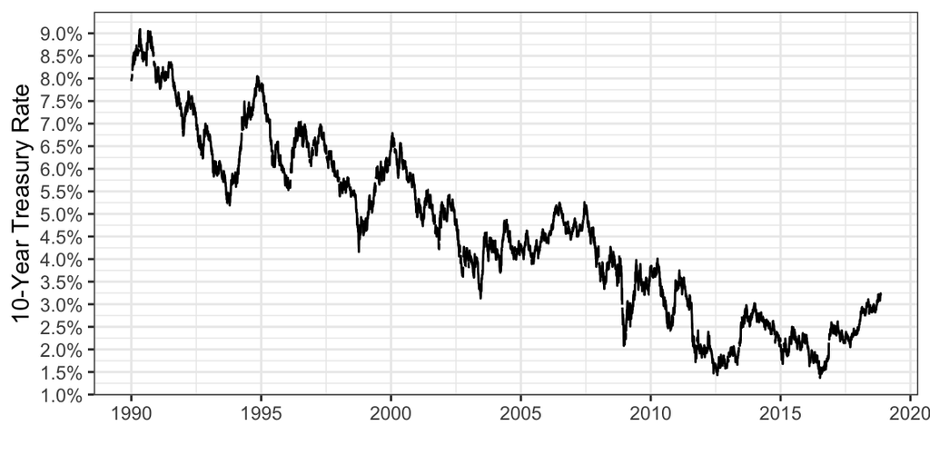

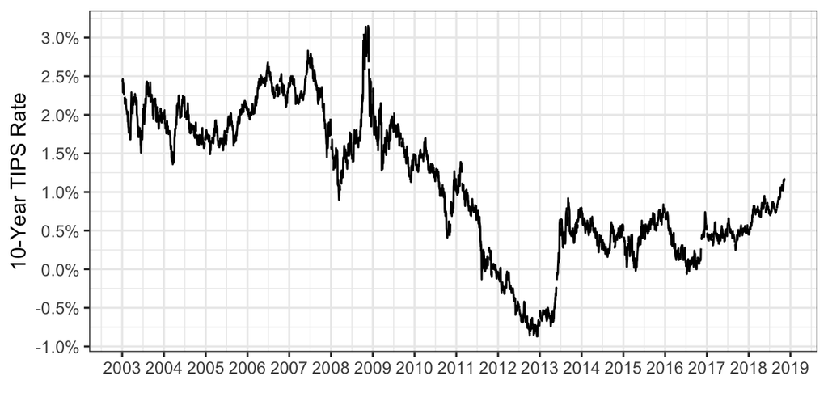

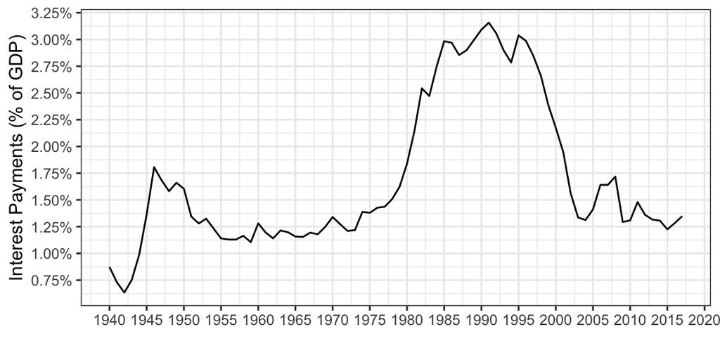

2. Or, one can measure the real interest rate is to look at the rate on the so-called Treasury Inflation Protected Securities (also called TIPS). Measuring the real interest rate in this way leads to an interest rate around 1%.

On the other hand, real GDP growth seems to be hovering around $g_Y \approx 2.5\%$. Real GDP per capita growth is variable, around 3.0% per year on average in the 1960s, 2.1% in the 1970s, 2.4% in the 1980s, 2.2% in the 1990s, 0.7% in the 2000s, and 0.9% from 2010 to 2017, while the growth rate of population is approximately 1%. Therefore, the ratio of government debt to GDP does not appear to be on an unsustainable path so far. Another way to see this is that the ratio of interest payments to GDP is not particularly high historically, which is also shown on the graphs. This implies that if the primary deficit was reduced to zero, the debt to GDP ratio would not be on an explosive trajectory.

# Public Debt in the Overlapping Generations Model

In this section, I illustrate using the overlapping-generations model of lecture 4 that public debt does not necessarily need to be repaid eventually, so that government debt is not necessarily a burden on future generations - an argument which we nonetheless often hear in the public debate. However, one precondition for this is naturally that the debt to GDP has to be stable. In other words, we need that $r^{*} \leq g_Y$. In the overlapping-generations model of lecture 4, we had $g_Y = 0$, since there was no long-run growth. So we want $r^{*} \leq 0$. In order to have a role for public debt, we will look at the model that we studied in Problem Set 3 called “Another Overlapping Generations Model” - the solution to this problem set was available here.

## Overlapping Generations Model

Let us look at a simplified version of the overlapping generations model we looked at in Lecture 4. For this model, we shall assume that people only care about old age consumption, and that they work only when young, receiving wage $w_{t}$. It does not really matter what the form of their utility function is with respect to old age consumption, because they will save everything anyway:
$$U=u(c_{t+1}^{o}).$$
Denoting by $r_t$ the (net) real interest rate, their intertemporal budget constraint is then given by:
$$c_{t}^{y}+\frac{c_{t+1}^{o}}{1+r_t}=w_{t}.$$
In this very simple environment, and because consumption in young age will always optimally be set to zero ($c_{t}^{y}=0$), this implies:
$$c_{t+1}^{o}=(1+r_t)w_{t}.$$
Similarly to the previous time, we assume that the labor force is fixed to unity ($L_{t}=\bar{L}=1$). The production function is Cobb-Douglas:
$$Y_{t}=K_{t}^{\alpha}L_{t}^{1-\alpha}.$$
Together with the previous assumption of constant labor $L_{t}=1$, this implies that:
$$Y_{t}=K_{t}^{\alpha}.$$
From firms’ optimality conditions, the wage is just the marginal product of labor:
$$w_{t}=\frac{\partial Y_{t}}{\partial L_{t}}=(1-\alpha)K_{t}^{\alpha}L_{t}^{-\alpha}=(1-\alpha)K_{t}^{\alpha}.$$
Similarly as previously, we also get through firms’ optimization on the amount of capital that:
$$r_t+\delta=\frac{\partial Y_{t}}{\partial K_{t}}=\alpha K_{t}^{\alpha-1}.$$
Finally, for simplicity, we shall sometimes assume that the depreciation rate is equal to $\delta=1=100\%$. In other words, capital fully depreciates each period - this is reasonable if you take one unit of time to represent one generation, or about 30 years - remember that the depreciation rate for one year was ranging from 5% to 10%.

## Without Government Debt

Let us first remind ourselves what happens in the absence of government debt in this model, as in lecture 4. In the absence of a government, we get even simpler expressions than the previous time. The law of motion for capital is given as follows:
$$\Delta K_{t+1}=w_{t}-\delta K_{t}.$$
Since $w_t$ is a fraction $1-\alpha$ of output, this law of motion corresponds to the Solow growth model with $s = 1-\alpha$. The law of motion for capital is:
$$K_{t+1}=(1-\alpha) K_{t}^{\alpha}+ (1-\delta)K_t.$$
This is a difference equation for sequence $K_{t}$ which converges to a steady state value for the capital stock $K^{*}$ such that:
$$\begin{aligned}
& \delta K^{*} = (1-\alpha)(K^*)^{\alpha}\\
& \quad \Rightarrow \quad K^{*}=\frac{(1-\alpha)^{\frac{1}{1-\alpha}}}{\delta^{\frac{1}{1-\alpha}}}.
\end{aligned}$$
The steady state value for the interest rate $r^{*}$ is then such that:
$$\begin{aligned}
r^{*}+\delta&=\alpha(K^{*})^{\alpha-1}\\
&= \alpha \left[\left(\frac{1-\alpha}{\delta}\right)^{\frac{1}{1-\alpha}}\right]^{\alpha-1}\\
r^{*}+\delta &=\frac{\delta \alpha}{1-\alpha}
\end{aligned}$$
Therefore, the steady-state value of the interest rate $r^{*}$:
$$r^{*} = \frac{2\alpha-1}{1-\alpha}\delta.$$
which, note, is negative for $\alpha < 1/2$. The steady state value for output $Y^{*}$ is then:
$$\begin{aligned}
Y^{*}&=\left(K^{*}\right)^{\alpha}\\
Y^{*}&=\frac{(1-\alpha)^{\frac{\alpha}{1-\alpha}}}{\delta^{\frac{\alpha}{1-\alpha}}}.
\end{aligned}$$
The value for the wage $w^{*}$ is:
$$\begin{aligned}
w^{*}&=(1-\alpha)\left(K^{*}\right)^{\alpha}\\
&=(1-\alpha) \left(\frac{1-\alpha}{\delta}\right)^{\frac{\alpha}{1-\alpha}}\\
w^{*} &= \frac{\left(1-\alpha\right)^{\frac{1}{1-\alpha}}}{\delta^{\frac{\alpha}{1-\alpha}}}
\end{aligned}$$
Steady-state consumption of the old $(c^{o})^{*}$ is thus given by:
$$\begin{aligned}
(c^{o})^{*}&=(1+r^*)w^{*}\\
(c^{o})^{*}&=\left(1+ \frac{2\alpha-1}{1-\alpha}\delta\right)\left(1-\alpha\right)^{\frac{1}{1-\alpha}}
\end{aligned}$$
**Full depreciation ($\delta = 1$).** Since one period here is one generation, a useful assumption is that capital fully depreciates in one period, so that $\delta = 1$. Then, the previous expressions are considerably more simple to work with:
$$\begin{aligned}
K^{*}&=\frac{(1-\alpha)^{\frac{1}{1-\alpha}}}{\delta^{\frac{1}{1-\alpha}}}=(1-\alpha)^{\frac{1}{1-\alpha}}\\
r^{*}&=\frac{2\alpha-1}{1-\alpha}\delta = \frac{2\alpha-1}{1-\alpha}\\
Y^{*}&=\frac{(1-\alpha)^{\frac{\alpha}{1-\alpha}}}{\delta^{\frac{\alpha}{1-\alpha}}} = (1-\alpha)^{\frac{\alpha}{1-\alpha}}\\
w^{*} &= \frac{\left(1-\alpha\right)^{\frac{1}{1-\alpha}}}{\delta^{\frac{\alpha}{1-\alpha}}} = (1-\alpha)^{\frac{1}{1-\alpha}}\\
(c^{o})^{*}&=\left(1+ \frac{2\alpha-1}{1-\alpha}\delta\right)\left(1-\alpha\right)^{\frac{1}{1-\alpha}}\\
&=\frac{\alpha}{1-\alpha}\left(1-\alpha\right)^{\frac{1}{1-\alpha}}\\
(c^{o})^{*}&= \alpha\left(1-\alpha\right)^{\frac{\alpha}{1-\alpha}}
\end{aligned}$$

**Numerical Application.** With $\delta = 1$ and $\alpha = 1/3$:
$$\begin{aligned}
K^{*}&=(1-\alpha)^{\frac{1}{1-\alpha}}=\left(\frac{2}{3}\right)^{3/2}=\frac{2\sqrt{2}}{3\sqrt{3}}\\
r^{*}&=\frac{2\alpha-1}{1-\alpha}=\frac{-1/3}{2/3}=-\frac{1}{2}=-50\%\\
Y^{*}&=(1-\alpha)^{\frac{\alpha}{1-\alpha}} = \left(\frac{2}{3}\right)^{1/2}=\frac{\sqrt{2}}{\sqrt{3}}\\
w^{*}&=\left(1-\alpha\right)^{\frac{1}{1-\alpha}} =\frac{2\sqrt{2}}{3\sqrt{3}}\\
(c^{o})^{*}&=\alpha\left(1-\alpha\right)^{\frac{\alpha}{1-\alpha}}=\frac{1}{3} \left(\frac{2}{3}\right)^{1/2}=\frac{\sqrt{2}}{3\sqrt{3}}
\end{aligned}$$

## With Government Debt

As we saw in lecture 2, and then again in lecture 4, because $r^{*}<0$ we have that the quantity of capital is higher than the Golden Rule level of the capital stock, which is such that $r^{*}_g=0$. Why, again, is the Golden rule interest rate equal to 0 when there is no growth ? One quick way to understand it is to write that in the steady-state, the consumption of the old $(c^{o})^{*}$ is supposed to be maximized (since the old are the only ones consuming). However, we also know that in the steady-state, total production $F(K^{*}, 1) = (K^{*})^{\alpha}$ is used for two things: consuming (for the old) and repairing the capital stock (saving equals investment equals depreciation, as in the Solow growth model), so that:
$$(c^{o})^{*} + \delta K^{*} = (K^{*})^{\alpha} \quad \Rightarrow \quad (c^{o})^{*} = (K^{*})^{\alpha} -\delta K^{*}$$
Therefore, the Golden rule capital stock $K^{*}_g$, which maximizes $(c^{o})^{*}$ solves:
$$\max_{K^{*}}\quad (K^{*})^{\alpha}-\delta K^{*},$$
which implies that:
$$\alpha (K^{*}_g)^{\alpha-1}=\delta.$$
Moreover, we know that the marginal product of capital $\partial F(K^{*}, 1)/\partial K^{*} = \alpha (K^{*}_g)^{\alpha-1}$ is also equal to $r^{*}_g+\delta$, the gross return, from the firms’ problem, which gives the following optimality condition:
$$\alpha (K^{*}_g)^{\alpha-1}=r^{*}_g+\delta.$$
Using these two last equalities allows to conclude that in this situation with no growth, the Golden rule interest rate is equal to zero since $r^{*}_g+\delta = \alpha (K^{*}_g)^{\alpha-1} =\delta$:
$$r^{*}_g=0.$$
However, we saw in the previous section that the *equilibrium* interest rate $r^{*}$ was negative, equal to -50%. Therefore, the capital stock is too high here. As we saw in lectures 2 and 4, one way to solve this problem would be to force everyone to save less, in order to decrease private saving; however this might be thought of as a little bit too intrusive. Another way to solve this problem is to use public debt (decrease public saving, to reduce total saving) in order to solve this problem of excess saving and excess investment.

In order to better understand which level of public debt is warranted, we look at the level of capital such that $r^{*}_g=0$ - which again, is the golden rule interest rate, since the rate of growth of output is $g_Y=0$. Thus, the corresponding Golden Rule level of the capital stock $K^{*}_g$ is such that:
$$r^{*}_g+\delta=\alpha (K^{*}_g)^{\alpha-1} \quad \Rightarrow_{r^{*}_g=0} \quad \delta=\alpha (K^{*}_g)^{\alpha-1}$$
Therefore:
$$\begin{aligned}
K^{*}_g=\frac{\alpha^{\frac{1}{1-\alpha}}}{\delta^{\frac{1}{1-\alpha}}}.
\end{aligned}$$
The Golden rule steady-state value for output $Y^{*}_g$ would be then:
$$\begin{aligned}
Y^{*}_g&=\left(K^{*}_g\right)^{\alpha}\\
Y^{*}_g&=\frac{\alpha^{\frac{\alpha}{1-\alpha}}}{\delta^{\frac{\alpha}{1-\alpha}}}.
\end{aligned}$$
The value for the steady-state wage $w^{*}_g$ is then:
$$\begin{aligned}
w^{*}_g&=(1-\alpha)\left(K^{*}\right)^{\alpha}\\
w^{*}_g&=(1-\alpha) \frac{\alpha^{\frac{\alpha}{1-\alpha}}}{\delta^{\frac{\alpha}{1-\alpha}}}
\end{aligned}$$
Steady-state consumption of the old $(c^{o})^{*}_g$ is thus given by:
$$\begin{aligned}
(c^{o})^{*}_g&=(1+r^*)w^{*}_g\\
(c^{o})^{*}_g&=(1-\alpha) \frac{\alpha^{\frac{\alpha}{1-\alpha}}}{\delta^{\frac{\alpha}{1-\alpha}}}
\end{aligned}$$
If $\delta = 1$, then:
$$(c^{o})^{*}_g=(1-\alpha) \alpha^{\frac{\alpha}{1-\alpha}}$$
The question is how to we achieve this quantity of capital $K^{*}_g$? The answer is that some public debt needs to be taken on by the government. Again, saving is equal to the wage $w^{*}_g$, and to the purchase of total assets, which includes both public debt whose quantity is given by $B^{*}_g$, and the capital stock whose quantity is $K^{*}_g$. Therefore, we may compute the level of the public debt which allows to reach this Golden-Rule level of capital accumulation:
$$B^{*}_g+K^{*}_g=w^{*}_g\quad\Rightarrow\quad B^{*}_g=w^{*}_g-K^{*}_g.$$
Substituting:
$$\begin{aligned}
B^{*}_g&=w^{*}_g-K^{*}_g\\
&=(1-\alpha) \frac{\alpha^{\frac{\alpha}{1-\alpha}}}{\delta^{\frac{\alpha}{1-\alpha}}}-\frac{\alpha^{\frac{1}{1-\alpha}}}{\delta^{\frac{1}{1-\alpha}}}\\
B^{*}_g&=\frac{\alpha^{\frac{\alpha}{1-\alpha}}}{\delta^{\frac{\alpha}{1-\alpha}}}\left(1-\alpha-\frac{\alpha}{\delta}\right).
\end{aligned}$$
Note that with $\delta = 1$, then this level of public debt is strictly positive when $\alpha <1/2$.

**Numerical Application.** With $\alpha = 1/3$ and $\delta = 1$:
$$\begin{aligned}
K^{*}_g&=\frac{\alpha^{\frac{1}{1-\alpha}}}{\delta^{\frac{1}{1-\alpha}}}=\left(\frac{1}{3}\right)^{3/2} = \frac{1}{3\sqrt{3}}\\
r_g^{*}&=0\\
Y_g^{*}&=\frac{\alpha^{\frac{\alpha}{1-\alpha}}}{\delta^{\frac{\alpha}{1-\alpha}}} = \left(\frac{1}{3}\right)^{1/2}=\frac{1}{\sqrt{3}}\\
w^{*}_g&=(1-\alpha) \frac{\alpha^{\frac{\alpha}{1-\alpha}}}{\delta^{\frac{\alpha}{1-\alpha}}}= \frac{2}{3}\sqrt{\frac{1}{3}} = \frac{2}{3\sqrt{3}}\\
(c^{o})^{*}_g&=(1+r^*_g)w^{*}_g=w^{*}_g = \frac{2}{3\sqrt{3}}
\end{aligned}$$
Note that the steady-state consumption of the old $(c^{o})^{*}_g$ is greater than the level of consumption achieved by the old without government debt since $2>\sqrt{2}$. But what is amazing is that the level of capital in this case is actually lower than the level of capital in the previous section. The government can force the economy into this level of capital accumulation by taking on debt. The level of debt $B^{*}_g$ that corresponds to that level of capital accumulation is given by:
$$\begin{aligned}
B^{*}_g&=w^{*}_g-K^{*}_g\\
&=\frac{2}{3\sqrt{3}}-\frac{1}{3\sqrt{3}}\\
B^{*}_g&=\frac{1}{3\sqrt{3}}.
\end{aligned}$$
The government can reach that level of debt by giving a transfer to the first generation of old, like the war veterans, who will then consume in the first period $t=0$ an amount equal to:
$$c_{0}^{o}=\frac{\sqrt{2}}{3\sqrt{3}}+\frac{1}{3\sqrt{3}}=\frac{1+\sqrt{2}}{3\sqrt{3}}.$$
All future generations thus consume more. With a lot of capital, there is such a thing as a free lunch! Public debt is a Ponzi scheme, but a beneficial one. Public debt allows to increase consumption for everyone, and it can be rolled over every period (note that the debt to GDP ratio stays constant, as GDP growth is zero in the long run, just as the long run interest rate is zero). This is true more generally even in the neoclassical model, provided that there is **dynamic inefficiency** ($r^*<g_Y$) to begin with.

# The Treasury View, and Say’s Law

The most controversial and also most important questions in macroeconomics revolve around the issue of the so-called **Treasury View**, and **Say’s law**. These are probably the most difficult, controversial, but also the most important questions for macroeconomics.

## Treasury View: The Effects of Deficit Spending on Investment

The *Treasury View* asserts that more government spending, either in the form of government purchases or of tax reductions, and therefore lower saving, necessarily leads to *crowd out* (reduce) an equal amount of investment spending. Conversely more saving, either by the government or by households, leads to more investment. The logic of this argument is rather straightforward: if there exists a finite amount of resources in the economy - in other words, output is supply-determined - then whatever is being saved goes to increase investment. Output is simply the sum of consumption, investment, and government spending, so that “necessarily” increasing government spending leads to crowd out either of every component:
$$\begin{aligned}
&Y = C+I+G\\
\quad & \Rightarrow \quad \left(Y- C-T\right)=I+\left(G-T\right) \\
\quad & \Rightarrow \quad \left(Y- C-T\right) + \left(T-G\right)=I
\end{aligned}$$
Therefore investment $I$ equals total saving, private saving $S=Y-C-T$ plus public saving $T-G$:
$$\boxed{I = \underbrace{\left(Y-C-T\right)}_{\text{Private Saving}} + \underbrace{(T-G)}_{\text{Public Saving}}}$$
The reason why this view is called the **Treasury View** is that it was advanced in the 1930s, during the Great Depression, by the staff of the British Chancellor of the Exchequer, Winston Churchill. When defending his 1929 budget, Winston Churchill explained:

> The orthodox Treasury view… is that when the Government borrows in the money market it becomes a new competitor with industry and engrosses to itself resources which would otherwise have been employed by private enterprise, and in the process raises the rent of money to all who have need of it.

What we have seen so far leads us to take a very constrasted perspective on the Treasury View:

- In the **Keynesian model** of lectures 7, 8, and 9, investment is not crowded out by public debt - in the simplest model of the goods market, investment is in fact fixed. In the accelerator model, $I=b_0 + b_1 Y$ so that investment depends only on sales, not on saving. According to this model, what the Treasury View misses is that output is not determined by supply, but it is instead determined by demand. Therefore, one cannot reason as if GDP was fixed: GDP is precisely what adjusts when saving is reduced, to maintain the equality between investment and total saving.
- In the **neoclassical model** of lectures 2 and 4 in contrast, investment is determined by total saving, and it moves flexibly in response to saving. According to this view, investment is indeed crowded out by public deficits. Note however that this does not mean that in the neoclassical model, government deficits are always bad. As we just saw, public deficits may be a good thing if the economy has too much capital to begin with.

This issue of the Treasury view was discussed a lot during the U.S. 2008 financial crisis, when policymakers were turning to economists for advice on the appropriate policy response. You can see some discussion of this issue in “Readings - To go further”. While Chicago economists were articulating the Treasury view in various different flavors, Keynesian economists were rejecting this notion very strongly - most notably Paul Krugman. Of course, whether the Treasury View is correct or not is ultimately an empirical question. We will present some empirical evidence on this issue during lecture 13.

## Say’s law: supply creates its own demand

Say’s law, named after Jean-Baptiste Say (1767 - 1832), has been summarized by J.M. Keynes as a statement that “supply creates its own demand”. Jean-Baptiste Say’s reasoning was straightforward:

> It is worthwhile to remark that a product is no sooner created than it, from that instant, affords a market for other products to the full extent of its own value. When the producer has put the finishing hand to his product, he is most anxious to sell it immediately, lest its value should diminish in his hands. Nor is he less anxious to dispose of the money he may get for it; for the value of money is also perishable. But the only way of getting rid of money is in the purchase of some product or other. Thus the mere circumstance of creation of one product immediately opens a vent for other products.

Thus, in Say’s opinion, supply created its own demand, and there could never be any aggregate demand shortages. In a [briefing](https://www.economist.com/economics-brief/2017/08/10/says-law-supply-creates-its-own-demand) on Say’s law, *The Economist* magazine writes:

> In Say’s time, as nowadays, the world economy combined strong technological progress with fitful demand, spurts of innovation with bouts of austerity. (…) On the other hand, global demand was damaged by failed ventures in South America and debilitated by the eventual downfall of Napoleon. In Britain government spending was cut by 40% after the Battle of Waterloo in 1815. Some 300,000 discharged soldiers and sailors were forced to seek alternative employment. The result was a tide of overcapacity, what Say’s contemporaries called a “general glut”. Britain was accused of inundating foreign markets, from Italy to Brazil, much as China is blamed for dumping products today. In 1818 a visitor to America found “not a city, nor a town, in which the quantity of goods offered for sale is not infinitely greater than the means of the buyers”. It was this “general overstock of all the markets of the universe” that came to preoccupy Say and his critics. In trying to explain it, Say at first denied that a “general” glut could exist. Some goods can be oversupplied, he conceded. But goods in general cannot. His reasoning became known as Say’s law: “it is production which opens a demand for products”, or, in a later, snappier formulation: supply creates its own demand.

Once again, we may contrast two very different perspectives on the Say’s law:

- In the **Keynesian model** of lectures 7, 8, and 9, supply does not create its own demand, as some resources (labor or capital) are idle. This allows government spending or tax cuts to have an effect on GDP, by utilizing some of these resources. The reason is that in this model, the desire to save does not necessarily translate into more investment, since investment is fixed or given by the overall level of GDP, which is depressed by more saving. This was the paradox of thrift of lecture 8: instead of increasing investment, a higher desire to save actually reduces output, which ends up depressing saving.
- In the **neoclassical model** of lectures 2 and 4 in contrast, investment is determined by total saving, and it moves flexibly in response to saving. According to this view, there can indeed never be a general glut: consumption increases aggregate demand, but saving increases it too, by stimulating more investment. True, there might be “too much capital”, when the capital stock is higher than the Golden rule level, but this is not a “general glut”. Thus, supply can be thought of as indeed “creating its own demand”.

How you stand on those two issues (the Treasury View and Say’s law) determines whether you are more a neoclassical or a Keynesian economist. We shall see during lecture 13 which concentrates on fiscal policy, what the data has to say of Say’s law. As we have seen however, Keynesians and neoclassicals agree on one thing: consumption is the sole purpose of all production, and there exists such a thing as “too much capital”, when $r^{*}<g_Y$. Whether that is the situation we are in, even after Donald Trump’s massive tax cuts, is still a controversial question.

# Readings - To go further

[Uriel H. Crocker and S. M. Macvane, “General Overproduction,” The Quarterly Journal of Economics 1, no. 3 (1887): 362–66.](https://doi.org/10.2307/1882763)

[Robert J. Barro, Government Spending Is No Free Lunch, *Wall Street Journal*, January 22, 2009.](https://search.proquest.com/docview/399114897/CBD1D9A468D04A85PQ/2?accountid=14512)

[Paul Krugman, A Dark Age of Macroeconomics (wonkish), *New York Times*, Jan 27, 2009](https://search.proquest.com/docview/1930920374/1A771BC8177A4FB7PQ/1?accountid=14512)

[Paul Krugman, Multipliers and Reality, New York Times Blog Post, June 3, 2015.](https://krugman.blogs.nytimes.com/2015/06/03/multipliers-and-reality/)

[In Japan, the Government Gets Paid to Borrow Money, *Wall Street Journal*, March 1, 2016.](https://search.proquest.com/docview/1768757479/E1052F8FA6974859PQ/1?accountid=14512)

(Gated) [Say’s Law: Supply Creates its Own Demand. *The Economist*, August 10, 2017.](https://www.economist.com/economics-brief/2017/08/10/says-law-supply-creates-its-own-demand)

(Gated) [Overlapping Generations: Kicking the road down an endless road. *The Economist*, August 31, 2017.](https://www.economist.com/economics-brief/2017/08/31/kicking-the-can-down-an-endless-road)

(Gated) [Why is macroeconomics so hard to teach? *The Economist*, August 9, 2018.](https://www.economist.com/finance-and-economics/2018/08/09/why-is-macroeconomics-so-hard-to-teach)

[“U.S. on a course to spend more on debt than defense”, *Wall Street Journal*, November 11, 2018.](https://search.proquest.com/docview/2131663609/B6DB7A44958C4606PQ/1?accountid=14512)

[^1]: Note however that automatic stabilizers go against that: in problem set 6, we even saw that tax cuts sometimes can pay for themselves. However, this happens only if the multiplier is really very high. For example, if tax cuts benefit agents with high marginal propensities to consume.
[^2]: It might seem a bit contradictory that a situation where the debt to GDP ratio goes to 0 automatically is called inefficient - this seems like a rather positive state of affairs. However, we shall see in the next chapter through the overlapping-generations model, that “dynamic inefficiency” means here that the government should in fact be taking on even *more* government debt, to restore an equality between $r$ and $g_Y$. You may also remember from Exercise 1 of problem set 4 - the solution is posted here - that an interest rate lower than the rate of growth implies that we are below the Golden Rule interest rate, so that the capital stock is too high, and consumption is too low.